# Integrated Project 1

### The top five genres in each region (NA, EU, JP)

```python
total_sales_per_genre_na = games_2.pivot_table(index='genre',
                      values='na_sales',
                      aggfunc = 'sum')
total_sales_per_genre_na = total_sales_per_genre_na.sort_values(['na_sales'], ascending=False)
total_sales_per_genre_na
```

| genre | na_sales |
| --- | --- |
| Action | 178.02 |
| Shooter | 144.81 |
| Sports | 81.53 |
| Role-Playing | 64.11 |
| Misc | 38.19 |
| Platform | 25.38 |
| Fighting | 19.79 |
| Racing | 17.30 |
| Adventure | 9.00 |
| Simulation | 8.43 |
| Strategy | 4.23 |
| Puzzle | 1.13 |

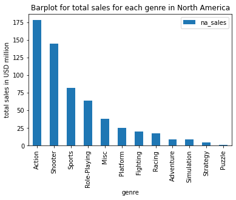

```python
total_sales_per_genre_na.plot(kind='bar');
plt.title("Barplot for total sales for each genre in North America");
plt.xlabel('genre');
plt.ylabel('total sales in USD million');
```

```python
total_sales_per_genre_eu = games_2.pivot_table(index='genre',
                      values='eu_sales',
                      aggfunc = 'sum')
total_sales_per_genre_eu = total_sales_per_genre_eu.sort_values(['eu_sales'], ascending=False)
total_sales_per_genre_eu
```

| genre | eu_sales |
| --- | --- |
| Action | 159.53 |
| Shooter | 113.49 |
| Sports | 69.09 |
| Role-Playing | 48.58 |
| Racing | 27.29 |
| Misc | 26.32 |
| Platform | 21.41 |
| Simulation | 14.55 |
| Fighting | 10.79 |
| Adventure | 9.46 |
| Strategy | 5.17 |
| Puzzle | 1.40 |

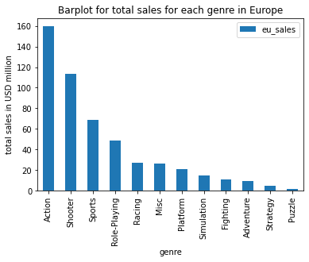

```python
total_sales_per_genre_eu.plot(kind='bar');
plt.title("Barplot for total sales for each genre in Europe");
plt.xlabel('genre');
plt.ylabel('total sales in USD million');
```

```python
total_sales_per_genre_jp = games_2.pivot_table(index='genre',
                      values='jp_sales',
                      aggfunc = 'sum')
total_sales_per_genre_jp = total_sales_per_genre_jp.sort_values(['jp_sales'], ascending=False)
total_sales_per_genre_jp
```

| genre | jp_sales |
| --- | --- |
| Role-Playing | 65.54 |
| Action | 52.80 |
| Misc | 12.86 |
| Simulation | 10.41 |
| Fighting | 9.44 |
| Shooter | 9.23 |
| Platform | 8.63 |
| Adventure | 8.24 |
| Sports | 8.03 |
| Strategy | 2.88 |
| Racing | 2.50 |
| Puzzle | 2.14 |

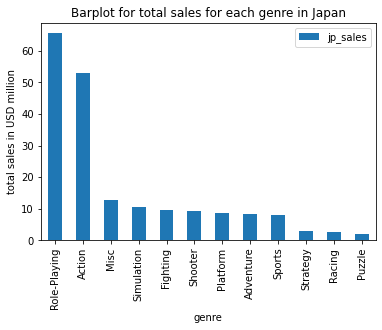

```python
total_sales_per_genre_jp.plot(kind='bar');
plt.title("Barplot for total sales for each genre in Japan");
plt.xlabel('genre');
plt.ylabel('total sales in USD million');
```

In terms of total sales for each genre:

- The top five genres in North America were Action, Shooter, Sports, Role-playing and Misc,with total sales ranged from 38 USD million to 178 USD million.
- The top five genres in Europe were Action, Shooter, Sports, Role-playing and Racing, with total sales ranged from 27 USD million to 160 USD million.
- The top five genres in Japan were Role-playing, Action, Misc, Simulation and Fighting, with total sales ranged from 9 USD million to 66 USD million.

In conclusion, genres had the largest market shares in North America and the smallest market shares in Japan. Market shares in Europe ranked in the second place. The top five most popular genres were similar in both North America and Europe. However, the Japan market had a quite different set of top five most popular genres.

### ESRB ratings and sales in individual regions

```python
total_sales_per_rating_na = games_2.pivot_table(index='rating',
                      values='na_sales',
                      aggfunc = 'sum')
total_sales_per_rating_na = total_sales_per_rating_na.sort_values(['na_sales'], ascending=False)
total_sales_per_rating_na
```

| rating | na_sales |
| --- | --- |
| M | 231.57 |
| E | 114.49 |
| E10+ | 75.96 |
| T | 66.31 |

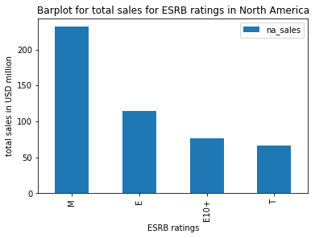

```python
total_sales_per_rating_na.plot(kind='bar');
plt.title("Barplot for total sales for ESRB ratings in North America");
plt.xlabel('ESRB ratings');
plt.ylabel('total sales in USD million');
```

```python
total_sales_per_rating_eu = games_2.pivot_table(index='rating',
                      values='eu_sales',
                      aggfunc = 'sum')
total_sales_per_rating_eu = total_sales_per_rating_eu.sort_values(['eu_sales'], ascending=False)
total_sales_per_rating_eu
```

| rating | eu_sales |
| --- | --- |
| M | 193.96 |
| E | 113.05 |
| E10+ | 55.56 |
| T | 53.01 |

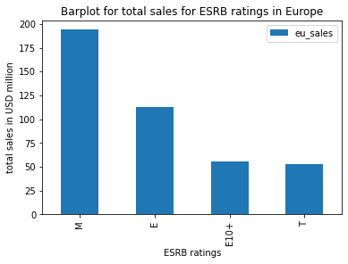

```python
total_sales_per_rating_eu.plot(kind='bar');
plt.title("Barplot for total sales for ESRB ratings in Europe");
plt.xlabel('ESRB ratings');
plt.ylabel('total sales in USD million');
```

```python
total_sales_per_rating_jp = games_2.pivot_table(index='rating',
                      values='jp_sales',
                      aggfunc = 'sum')
total_sales_per_rating_jp = total_sales_per_rating_jp.sort_values(['jp_sales'], ascending=False)
total_sales_per_rating_jp
```

| rating | jp_sales |
| --- | --- |
| E | 28.33 |
| T | 26.09 |
| M | 21.20 |
| E10+ | 8.19 |

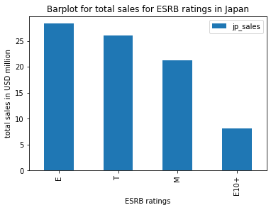

```python
total_sales_per_rating_jp.plot(kind='bar');
plt.title("Barplot for total sales for ESRB ratings in Japan");
plt.xlabel('ESRB ratings');
plt.ylabel('total sales in USD million');
```

In terms of total sales for each ESRB rating:

- In North America, ratings with M, E, E10+ and T had sales of 232, 114, 76, and 66 USD millions, respectively.
- In Europe, ratings with M, E, E10+ and T had sales of 194, 113, 56, and 53 USD millions, respectively.
- In Japan, ratings with E, T, M, and E10+ had sales of 28, 26, 21, and 8 USD millions, respectively.

In conclusion, in both North America and Europe, ratings with Mature (M) had the highest sales and ratings with Teen (T) had the lowest sales. However, in Japan, ratings with Mature (M) and Teen (T) had comparable sales. These findings indicate that ESRB ratings affected sales in individual regions, which might reflect different regional regulations for gaming in various countries.

## Statistical hypotheses testing

### Average user ratings of the Xbox One and PC platforms

Let's test the hypothesis that the average user ratings of the Xbox One and PC platforms are the same. That is, we want to test: $$ H_0: \mu_{1} = \mu_{2}$$ $$ H_1: \mu_{1} \ne \mu_{2}$$ where $\mu_{1}$ is average user ratings of the Xbox One, and $\mu_{2}$ is average user ratings of PC platforms.

We will use alpha = 0.05 and hypothesis test on the equality of two population means.

```python
games_2

games_2['platform'].value_counts()
```

```
PS3     493
PSV     412
3DS     404
PS4     392
X360    292
PC      250
XOne    247
PSP     173
WiiU    147
Wii      54
DS       31
Name: platform, dtype: int64
```

```python
# games_2[games_2['platform']=="XOne"]['user_score']
```

```python
# Test the hypotheses
alpha = 0.05

results = st.ttest_ind(games_2[games_2['platform']=="XOne"]['user_score'],
                       games_2[games_2['platform']=="PC"]['user_score'])
print('p-value:', results.pvalue)
```

```
p-value: 0.389290928461952
```

```python
if results.pvalue < alpha:
    print("We reject the null hypothesis.")
else:
    print("We can't reject the null hypothesis.")
```

```
We can't reject the null hypothesis.
```

Thus, we conclude that the data did not provide enough evidence to show that the average user ratings of the Xbox One and PC platforms were different.

### Average user ratings for the Action and Sports genres

Let's test the hypothesis that the average user ratings for the Action and Sports genres are different. That is, we want to test: $$ H_0: \mu_{1} = \mu_{2}$$ $$ H_1: \mu_{1} \ne \mu_{2}$$ where $\mu_{1}$ is average user ratings for the Action genre, and $\mu_{2}$ is average user ratings for the Sports genre.

We will use alpha = 0.05 and hypothesis test on the equality of two population means.

```python
games_2

games_2['genre'].value_counts()
```

```
Action          1032
Role-Playing     372
Adventure        303
Sports           269
Shooter          236
Misc             192
Racing           116
Fighting         109
Platform          85
Simulation        82
Strategy          71
Puzzle            28
Name: genre, dtype: int64
```

```python
# Test the hypotheses
alpha = 0.05

results = st.ttest_ind(games_2[games_2['genre']=="Action"]['user_score'],
                       games_2[games_2['genre']=="Sports"]['user_score'])
print('p-value:', results.pvalue)
```

```
p-value: 1.0712266605621589e-25
```

```python
if results.pvalue < alpha:
    print("We reject the null hypothesis.")
else:
    print("We can't reject the null hypothesis.")
```

```
We reject the null hypothesis.
```

Thus, we conclude that the data provide enough evidence to show that the average user ratings for the Action and Sports genres are different.

## General conclusion

In this project, we analyzed the games dataset from the online store Ice, which sells video games all over the world. The major steps for analyzing the data are:

1. Load the dataset and perform initial data exploration
2. Fix and enrich data by changing data types and creating new variables when appropriate
3. Fill in missing values in some columns
4. Use data aggregation, pivot tables, barplots to draw insights about sales across platforms, regions and genres
5. Perform statistical hypothesis tests to check whether the average user ratings of the Xbox One and PC platforms are the same
6. Perform statistical hypothesis tests to check whether the average user ratings for the Action and Sports genres are different